# Лабораторная работа №9

Командная оболочка Midnight Commander

Липатников Андрей

1032253853@rudn.ru

Российский университет дружбы народов

2026-10-08

# Информация

## Докладчик

- Липатников Андрей
- Студент НКАбд-04-25
- Российский университет дружбы народов
- 1032253853@rudn.ru

# Вводная часть

## Актуальность

- mc объединяет просмотр, поиск, копирование и редактирование файлов
- операции в два-три нажатия клавиш вместо набора команд
- встроенный редактор — часть оболочки

## Объект и предмет исследования

- Объект — командная оболочка Midnight Commander
- Предмет — операции с файлами и каталогами средствами mc: навигация, меню, встроенный редактор

## Цели и задачи

- Цель: освоение основных возможностей командной оболочки Midnight Commander; приобретение навыков практической работы по просмотру каталогов и файлов; манипуляций с ними.
- Задачи:
  - изучить справку `man mc` и структуру mc
  - освоить операции с панелями и файлами
  - освоить меню панелей, Файл, Команда, Настройки
  - освоить редактирование во встроенном редакторе
  - отработать подсветку синтаксиса

## Материалы и методы

- операционная система: Fedora 41 (графическая среда Sway), оболочка bash
- инструментальные средства: Midnight Commander, справка `man`
- выполнено 21 снимок: задания 7.3.1 (1–7) и 7.3.2 (1–6)
- цикл: справка — задание — скриншот — отчёт

# Ход работы

## Панели и функциональные клавиши

Таблица 1: Функциональные клавиши mc

| Клавиша | Действие |
| --- | --- |
| [F3] | Просмотр файла |
| [F4] | Вызов встроенного редактора |
| [F5] | Копирование в каталог второй панели |
| [F6] | Перенос в каталог второй панели |
| [F10] | Выход из mc |

Панели: Ctrl-u — поменять местами, Ctrl-o — отключить

## Меню mc

- Файл: просмотр, правка, копирование, каталог, удаление
- Команда: поиск файла, дерево каталогов, история команд
- Настройки: Full screen, Double Width, Show Hidden Files

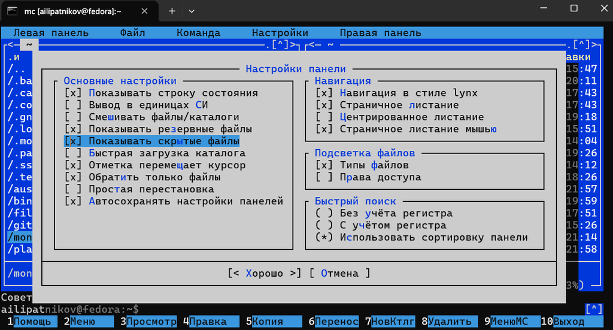

Меню Настройки mc

## Поиск и навигация

- поиск файла по расширению и строке в подменю Команда
- дерево каталогов — структура системы
- форматы списка: стандартный и расширенный

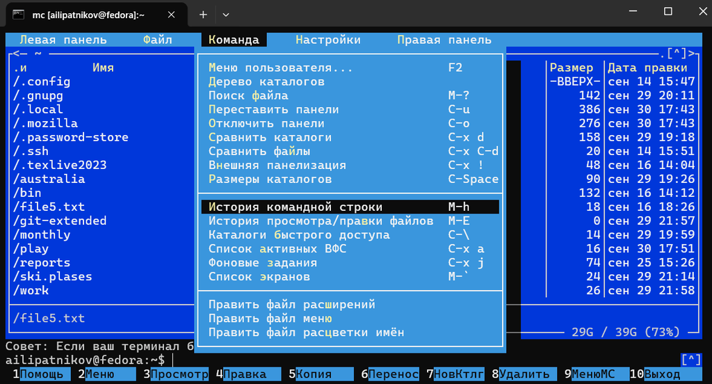

Поиск файла через меню Команда

## Редактор mc

Поиск [F7], повтор поиска [F17], замена [F4]; сохранение [F2], выход [F10]

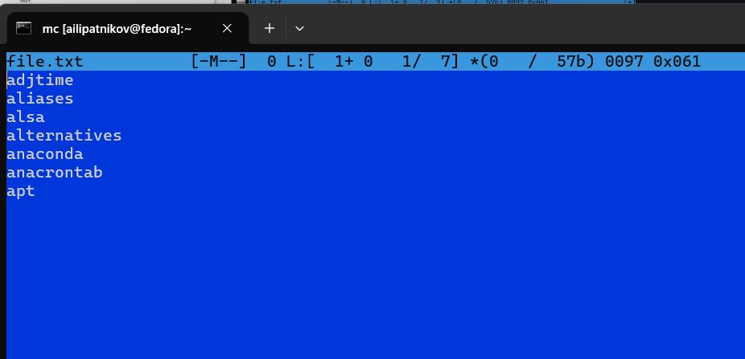

# Результаты

## Сводка результатов

Таблица 3: Сводка результатов выполнения заданий

[output not shown]

# Заключение

## Главный вывод

# Резерв

## Справка и запуск

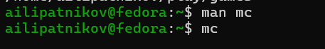

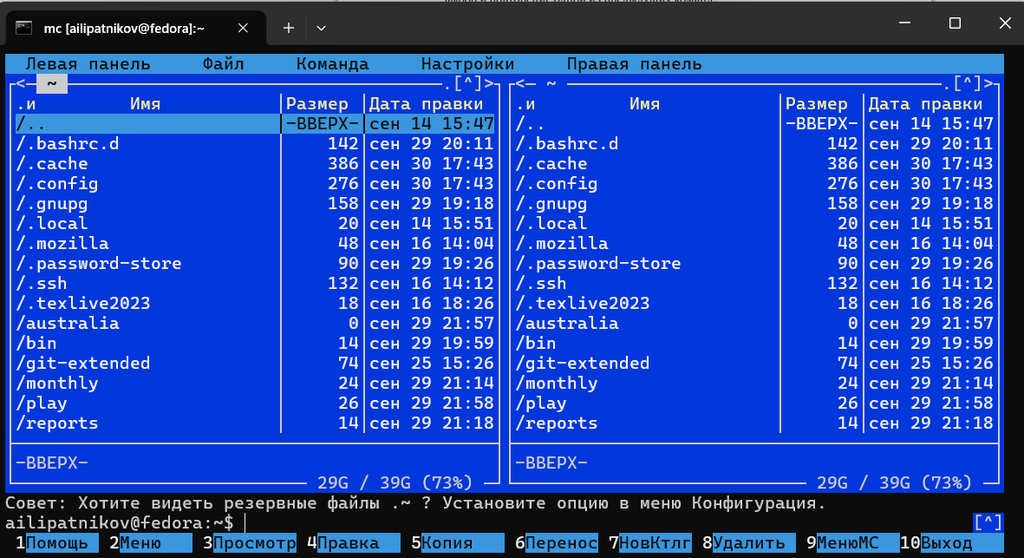

## Панели и операции

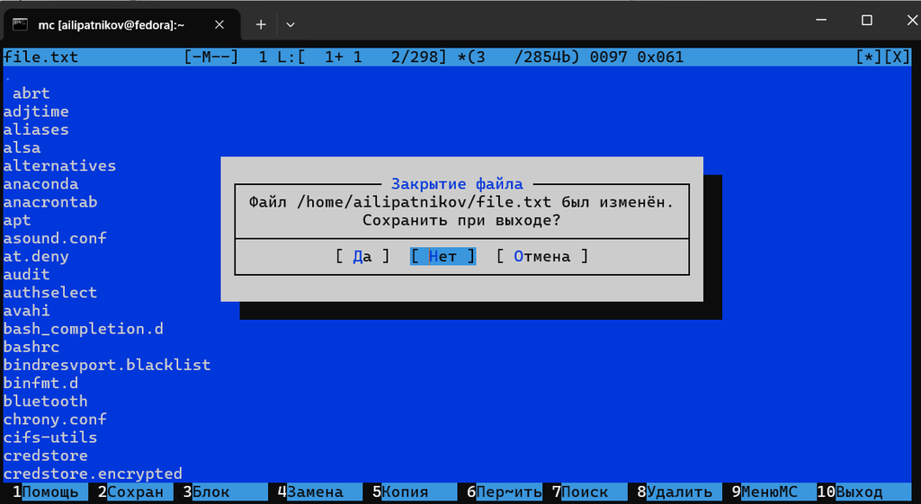

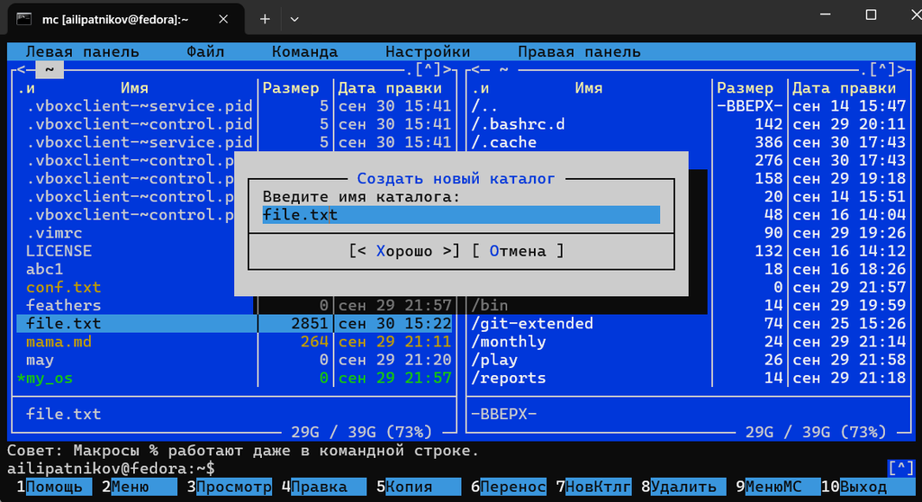

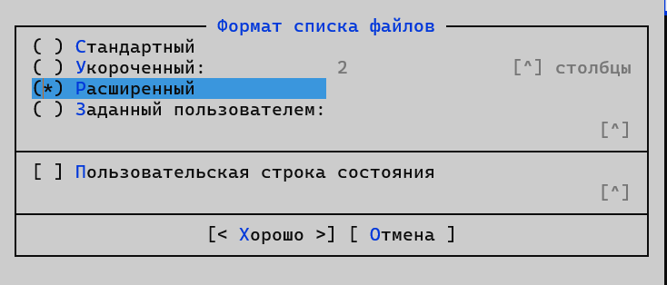

## Меню Файл

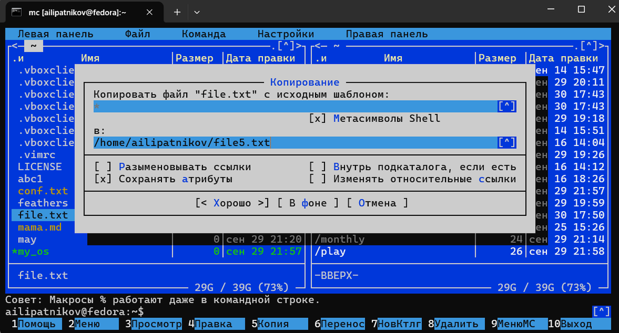

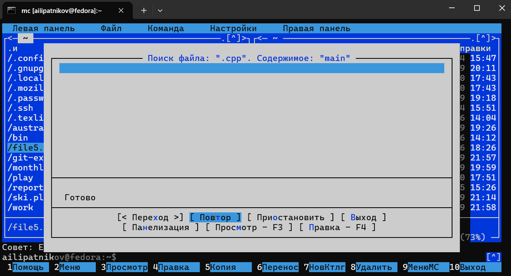

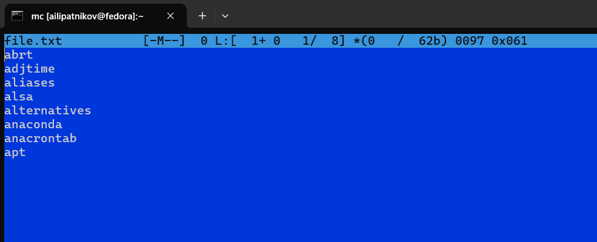

## Меню Команда

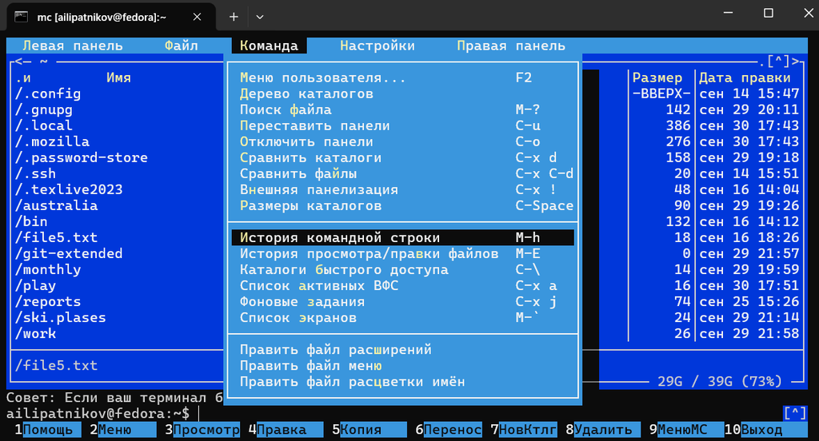

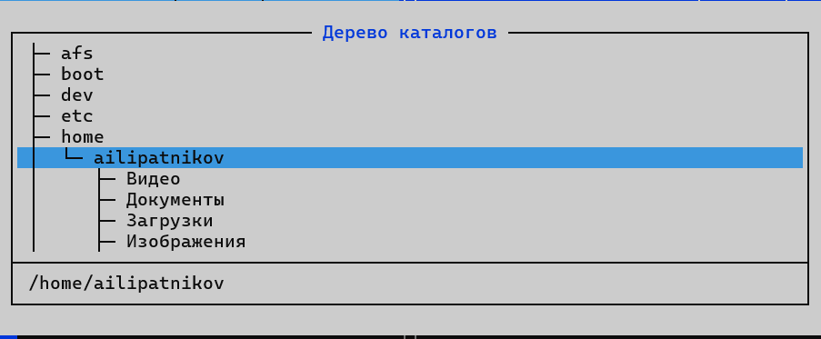

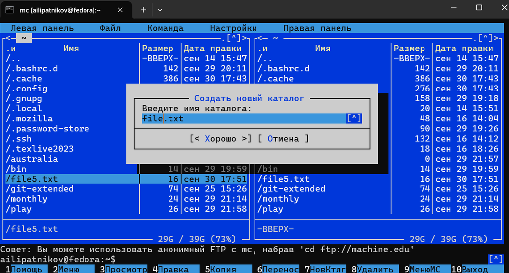

## Меню Настройки

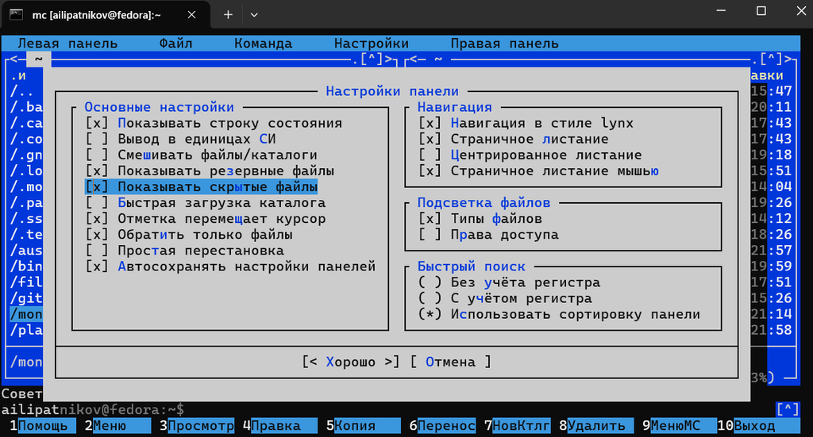

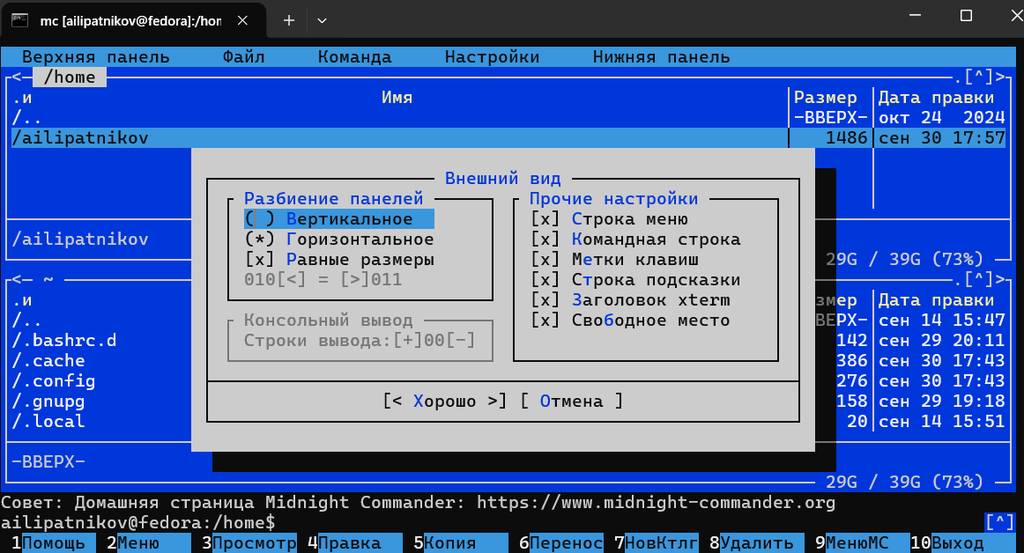

## Редактор — правка и фрагменты

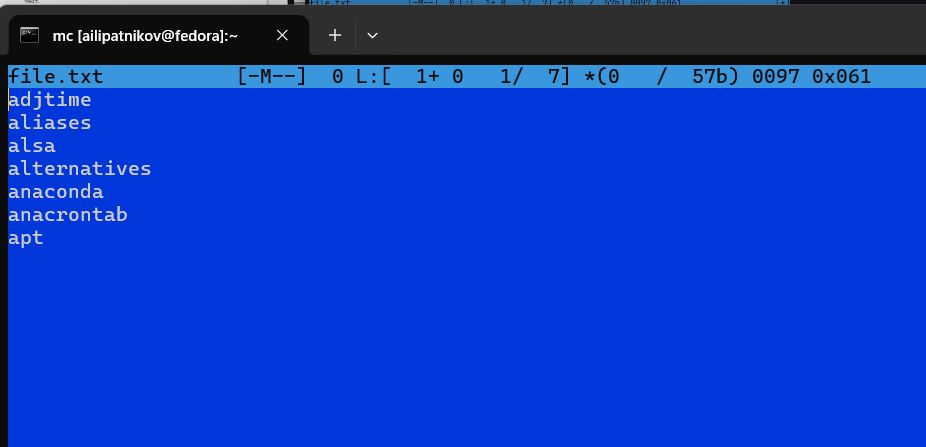

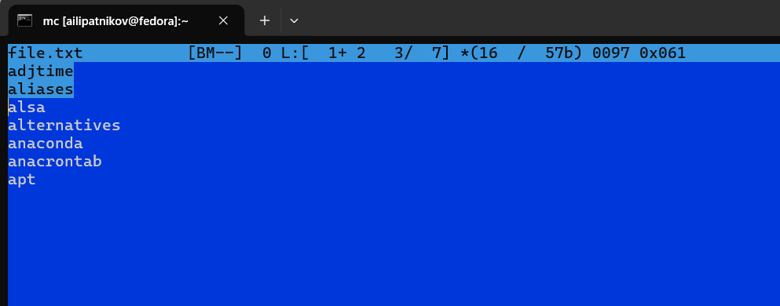

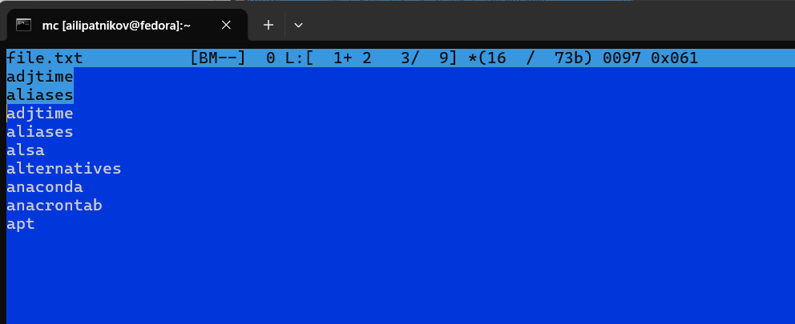

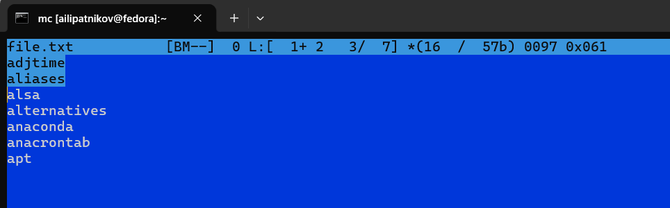

## Редактор — навигация и подсветка

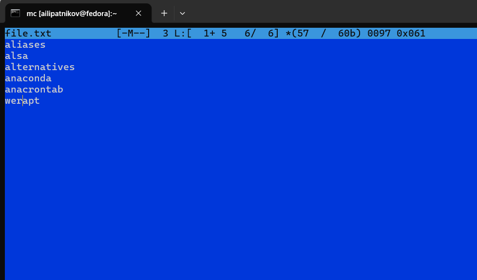

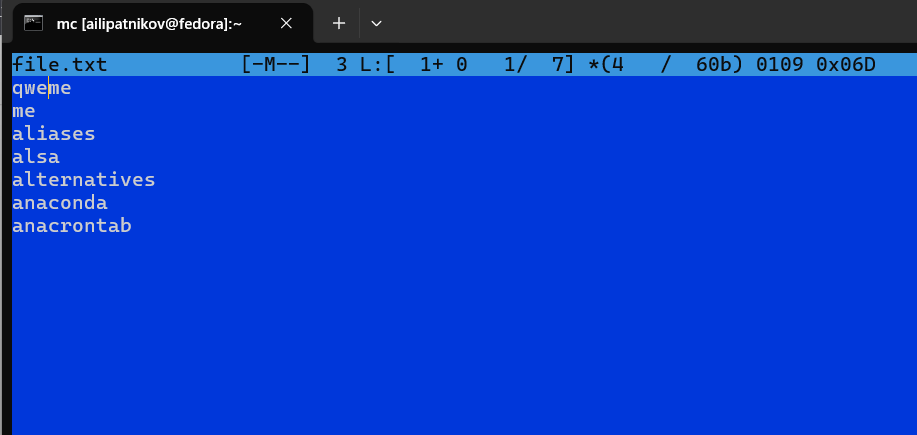

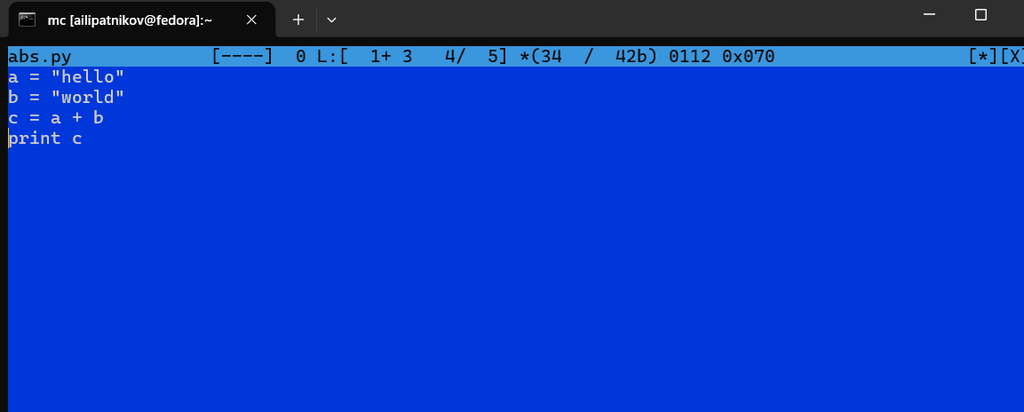

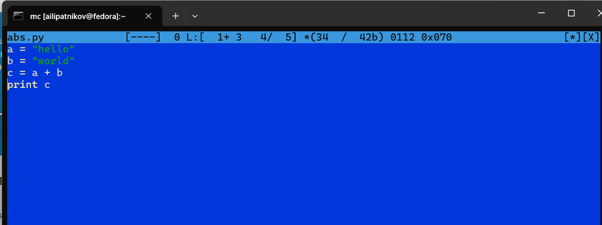